# HE Assignment 5 – Regression

W Kelly, Eric Boyle, Quaidzoher Dhilla, Brandon Hyer, Christian Mukania, Vinh Tran

7/9/2021

# Load Libraries

```r
library(tidyverse)
library(magrittr)
library(lubridate)
```

```r
library(corrplot)
```

# Read in hmdaInterestRate.rds file

```r
df <- read_rds("hmdaInterestRate.rds")
```

# Report Structure of dataframe

```r
str(df)
```

```
## 'data.frame':    6509 obs. of  14 variables:
##  $ activity_year            : Factor w/ 2 levels "2019","2018": 2 2 2 2 2 2 2 2 2 2 ...
##  $ state_code               : Factor w/ 1 level "IL": 1 1 1 1 1 1 1 1 1 1 ...
##  $ county_code              : Factor w/ 3 levels "Missing","Coles",..: 1 1 1 1 2 1 1 1 1 1 ...
##  $ aus_1                    : Factor w/ 6 levels "Desktop Underwriter (DU)",..: 2 1 3 4 1 4 1 1 1 1 ...
##  $ loan_purpose             : Factor w/ 6 levels "Home purchase",..: 2 3 1 1 3 3 1 1 1 1 ...
##  $ applicant_ethnicity_1    : Factor w/ 8 levels "Not Hispanic or Latino",..: 2 1 1 1 2 1 1 1 1 1 ...
##  $ applicant_sex            : Factor w/ 4 levels "Male","Female",..: 1 2 1 1 3 1 1 1 2 1 ...
##  $ derived_loan_product_type: Factor w/ 6 levels "Conventional:First Lien",..: 1 1 1 2 4 2 1 1 1 1 ...
##  $ interest_rate            : num  3.62 4.99 4.12 4.25 3.99 ...
##  $ loan_amount              : num  185000 105000 255000 255000 95000 205000 235000 105000 275000 75000 ...
##  $ loan_term                : num  180 360 360 360 240 360 360 360 360 360 ...
##  $ property_value           : num  235000 215000 265000 255000 105000 265000 335000 265000 285000 85000 ...
##  $ income                   : num  154000 88000 66000 89000 81000 61000 84000 76000 160000 35000 ...
##  $ applicant_age            : num  50 50 30 50 60 40 30 50 30 30 ...
```

# Divide by 1,000 for columns loan_amount, property_value, and income

```r
df$loan_amount <- df$loan_amount / 1000
df$property_value <- df$property_value / 1000
df$income <- df$income / 1000
```

# Create new column “Itp” dividing loan_amount by property_value

```r
df$Itp <- df$loan_amount / df$property_value
```

# Filter Data to keep observations which income is less than 300 (i.e. $300,000)

```r
df <- df %>% filter(income < 300)
```

# Report Summary of all Columns

```r
summary(df)
```

```
##  activity_year state_code     county_code
##  2019:3151     IL:6267    Missing   :5389
##  2018:3116                Coles     : 733
##                           Cumberland: 145
##
##
##
##
##                                                    aus_1
##  Desktop Underwriter (DU)                             :3091
##  Not applicable                                       : 941
##  Loan Propspector (LP) or Loan Product Advisor        :1548
##  Technology Open to Approved Lenders (TOTAL) Scorecard: 470
##  Guaranteed Underwriting System                       : 158
##  Other                                                :  59
##
##                loan_purpose                            applicant_ethnicity_1
##  Home purchase       :3945   Not Hispanic or Latino               :5558
##  Refinancing         :1002   Information not provided by applicant: 475
##  Cash-out refinancing: 824   Hispanic or Latino                   : 204
##  Other purpose       : 247   Other Hispanic or Latino             :  14
##  Home improvement    : 248   Mexican                              :  11
##  Not applicable      :   1   Not applicable                       :   2
##                              (Other)                              :   3
##                                  applicant_sex
##  Male                                   :3869
##  Female                                 :2063
##  information not provided by applicant  : 332
##  Applicant selected both male and female:   3
##
##
##
##                  derived_loan_product_type interest_rate    loan_amount
##  Conventional:First Lien      :4678        Min.   :2.400   Min.   :  5.0
##  FHA:First Lien               : 605        1st Qu.:3.990   1st Qu.: 85.0
##  Conventional:Subordinate Lien: 485        Median :4.500   Median :125.0
##  VA:First Lien                : 319        Mean   :4.516   Mean   :143.3
##  FSA/RHS:First Lien           : 179        3rd Qu.:4.990   3rd Qu.:185.0
##  FHA:Subordinate Lien         :   1        Max.   :6.980   Max.   :785.0
##
##    loan_term     property_value      income       applicant_age
##  Min.   :  6.0   Min.   : 15.0   Min.   :  1.00   Min.   :30.00
##  1st Qu.:240.0   1st Qu.:115.0   1st Qu.: 51.00   1st Qu.:30.00
##  Median :360.0   Median :165.0   Median : 77.00   Median :40.00
##  Mean   :307.2   Mean   :193.2   Mean   : 89.31   Mean   :45.53
##  3rd Qu.:360.0   3rd Qu.:245.0   3rd Qu.:114.00   3rd Qu.:60.00
##  Max.   :480.0   Max.   :925.0   Max.   :299.00   Max.   :70.00
##
##       Itp
##  Min.   :0.01408
##  1st Qu.:0.69697
##  Median :0.80822
##  Mean   :0.76296
##  3rd Qu.:0.93103
##  Max.   :1.26667
##
```

# Corr plot for interest_rate, Itp, income, applicant_age, property_value, and loan_amount

```r
df_corr <- cor(df[,c('interest_rate', 'Itp', 'income','applicant_age','property_value','loan_amount')])
df_corr
```

```
##                interest_rate        Itp      income applicant_age
## interest_rate     1.00000000 -0.3188587 -0.04683836   0.109516616
## Itp              -0.31885873  1.0000000 -0.13544451  -0.339076509
## income           -0.04683836 -0.1354445  1.00000000   0.045085985
## applicant_age     0.10951662 -0.3390765  0.04508598   1.000000000
## property_value   -0.16659083 -0.1658255  0.58661218   0.003786898
## loan_amount      -0.33150222  0.3903140  0.46424427  -0.168519166
##                property_value loan_amount
## interest_rate    -0.166590831  -0.3315022
## Itp              -0.165825527   0.3903140
## income            0.586612176   0.4642443
## applicant_age     0.003786898  -0.1685192
## property_value    1.000000000   0.8000781
## loan_amount       0.800078124   1.0000000
```

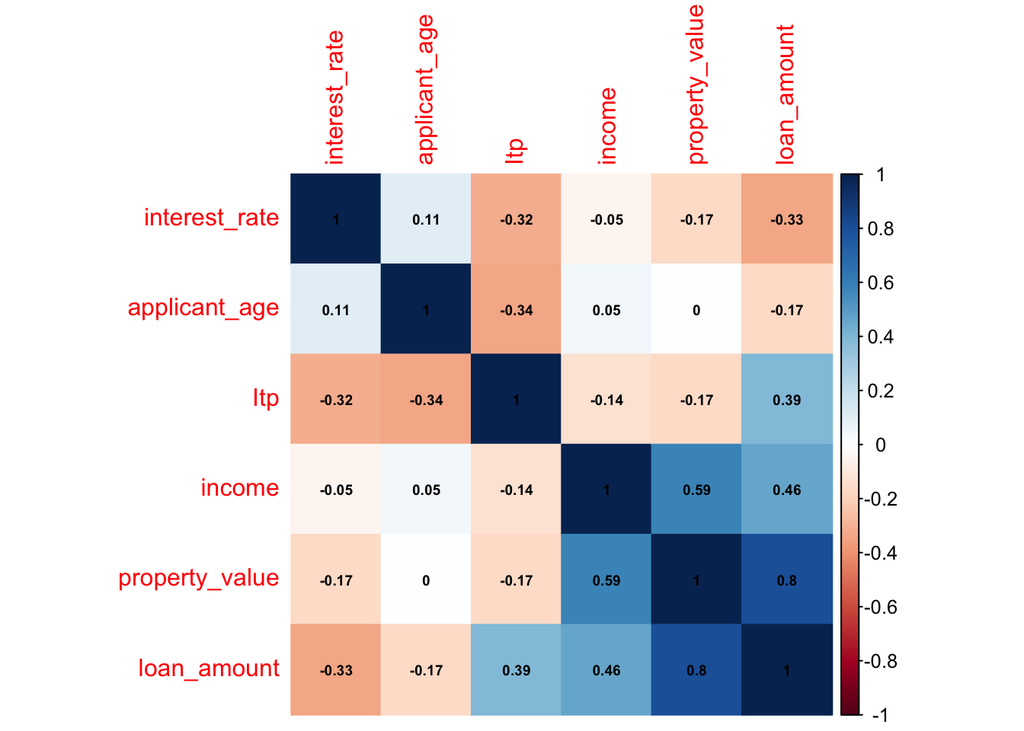

```r
corrplot(df_corr
         , method = 'color' # I also like pie and ellipse
         , order = 'hclust' # Orders the variables so that ones that behave similarly are placed next to each other
         , addCoef.col = 'black'
         , number.cex = .6 # Lower values decrease the size of the numbers in the cells
         )
```

***Below the plot, identify what variable has the strongest negative correlation with interest_rate. Comment on what might explain why that correlation is negative.

The Variable with the strongest negative correlation is “loan_amount” (-0.33)

The correlation b/t loan amount and interest rates are negative b/c the higher the loan amount the lower the interest rate due to the larger down payment because lenders see a lower level of risk when you have more at stake in the property compared to smaller loan amounts.